# How to Draw an Owl Workshop, Access 2019

### How to draw an owl

[figure not shown]

### R Workshop

### WHO AM I

### WHO ARE YOU

### What Is R?

- It's a *programming language* for statistical computing and visualization
- You can think of it as a *domain specific language* for stats and visualization, like Rails is for web development.

### Why R?

### Other software

- Python
- Julia
- Tableau
- PowerBI etc

### PYTHON IS BETTER (usually)

### RStudio

### Rstudio cloud

https://rstudio.cloud

### R ITSELF

```r
1 + 2
```

```
[1] 3
```

### Making Dice

```r
dice <- c(1,2,3,4,5,6)
dice
```

```
[1] 1 2 3 4 5 6
```

```r
dice <- 1:6
dice
```

```
[1] 1 2 3 4 5 6
```

- These are *vectors*, which is what R calls one-dimensional lists of things.
- What's with the weird “<-” thing? Why not *=* as in every other language ever invented in the history of languages?

### What are functions?

### Let's make a function!

```r
hello <- function(name="Access Attendee") {
  paste("Hello, ", name, "!", sep="")
}
hello()
```

```
[1] "Hello, Access Attendee!"
```

- Let's break this down:
- *hello* – the name of the function. This is an arbitrary name and can be almost anything.
- <- the assignment operator
- *function* - telling R we are building a function
- *name* - a variable to pass to the function. Functions can have multiple variables!

### Let's make a function!

```r
hello <- function(name="Access Attendee") {
  paste("Hello, ", name, "!", sep="")
}
```

- *paste* - to *concatenate* vectors
- “Hello, ” a string
- *name* again - the variable for the function. It can change!
- “!”, another string the end of our sentence.
- *sep*, a flag for paste to tell it what the separator is. In this case, we don't want any separator.
- Why did I write this function with “Access Attendee” in it?
- How can we run this and change the name?

### Rolling the Dice

```r
roll <- function(die = 1:6, rolls = 2) {
  dice <-sample(die, size = rolls)
  dice
}
roll()
```

```
[1] 1 6
```

- How can we change the number of dice sides? The number of rolls?
- Roll the dice a few times. Can you spot anything weird?

### Fixing our Dice

```r
?sample
```

```r
roll <- function(die = 1:6, rolls = 2) {
  dice <- sample(die, size = rolls, replace = TRUE)
  dice
}
roll()
```

```
[1] 1 5
```

### Let's make the function do the adding

```r
roll <- function(die = 1:6, rolls = 2) {
  dice <- sample(die, size = rolls, replace = TRUE)
  sum(dice)
}
roll()
```

```
[1] 12
```

### Let's make graphs!

### What are packages?

```r
install.packages("tidyverse")
library(tidyverse)
```

### Quick and Dirty Plotting with a Single Vector

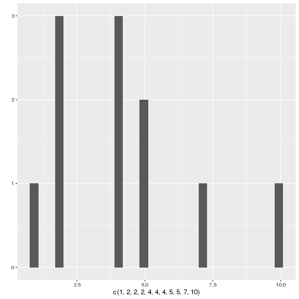

```r
qplot(c(1,2,2,2,4,4,4,5,5,7,10))
```

### Quick and Dirty Plotting with Two Vectors

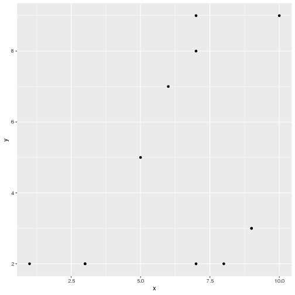

```r
x <- c(1,3,3,5,6,7,7,7,8,9,9,10)
y <- c(2,2,2,5,7,8,9,2,2,3,3,9)
qplot(x,y)
```

### Rolling many times

```r
replicate(10, roll())
```

- What do you think this does?

```
 [1]  3  9 11  5  8  4 12  7  8  8
```

- What happens if we change the first variable?
- Can we adjust the parameters of roll()?

### Plotting dice rolls

```r
rolls <- replicate(10000, roll())
```

### Plotting dice rolls

```r
qplot(rolls, binwidth=1)
```

- Without actually running this, what do you think this bar graph will look like?

### Plotting dice rolls

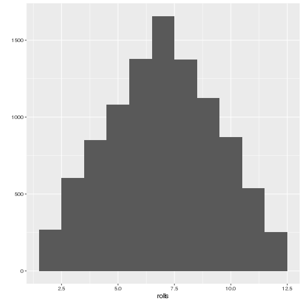

### Let's cheat

```r
rollcheat <- function(die = 1:6, rolls = 2) {
  dice <- sample(die, size = rolls, replace = TRUE, prob = c(1/8, 1/8, 1/8, 1/8, 1/8, 3/8))
  sum(dice)
}
rollcheat()
```

```
[1] 4
```

- How can we change which side is weighted?

### Plotting cheating rolls

```r
cheatrolls <- replicate(10000, rollcheat())
qplot(cheatrolls, binwidth = 1)
```

- What is the graph going to look like now?

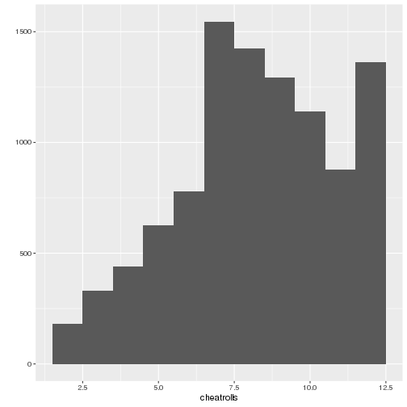

### Using more complicated data

```r
mpg
```

```
# A tibble: 234 x 11
   manufacturer model displ  year   cyl trans drv     cty   hwy fl    class
   <chr>        <chr> <dbl> <int> <int> <chr> <chr> <int> <int> <chr> <chr>
 1 audi         a4      1.8  1999     4 auto… f        18    29 p     comp…
 2 audi         a4      1.8  1999     4 manu… f        21    29 p     comp…
 3 audi         a4      2    2008     4 manu… f        20    31 p     comp…
 4 audi         a4      2    2008     4 auto… f        21    30 p     comp…
 5 audi         a4      2.8  1999     6 auto… f        16    26 p     comp…
 6 audi         a4      2.8  1999     6 manu… f        18    26 p     comp…
 7 audi         a4      3.1  2008     6 auto… f        18    27 p     comp…
 8 audi         a4 q…   1.8  1999     4 manu… 4        18    26 p     comp…
 9 audi         a4 q…   1.8  1999     4 auto… 4        16    25 p     comp…
10 audi         a4 q…   2    2008     4 manu… 4        20    28 p     comp…
# … with 224 more rows
```

- *mpg* is a *data frame* or, in Tidyverse-speak, a *tibble*
- it's basically a spreadsheet.

### The View function makes this a little more palatable

```r
View(mpg)
```

### Doing something interesting with the dataset

- How can we determine the median highway gas mileage?

```r
median(mpg %>% pull(9))
```

```
[1] 24
```

- breaking this down:
- *median* – (a function, to which we pass a vector)
- *mpg* – (our dataset)
- *%>%* – a “pipe” through which data is passed (from tidyverse/magrittr)
- *pull* – a function to convert a table to a vector
- *9* – we want to convert the ninth column of the *mpg* dataset, which is “hwy”.
- You can make this *without* the weird *%>%* pipe thing, but using pipes (usually) makes code much more readable.

### How to make graphs if you have no art in your soul

```r
library(tidyverse)
?ggplot
```

### ggplot

- The “gg” stands for *grammar of graphics*
- ggplots are built out of two basic pieces
- the *dataset*, like *mpg*
- the “geom”, how to draw the dataset.

### ggplot #2

```r
ggplot(mpg)
```

- What will this do?
- *Why* did it do that?

### ggplot #3

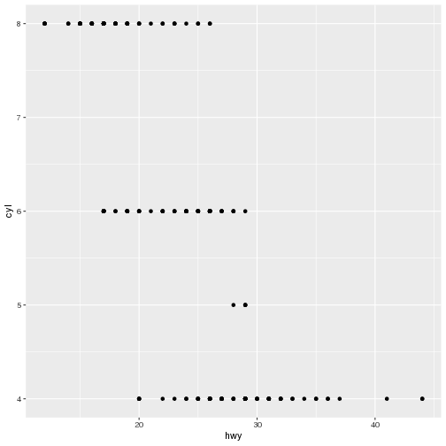

```r
ggplot(mpg) + geom_point(aes(x = hwy, y = cyl))
```

- What can we learn from this graph?

### adding a third dimension

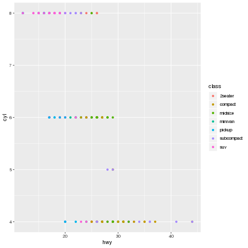

```r
ggplot(mpg) + geom_point(aes(x = hwy, y = cyl, colour = class))
```

### another

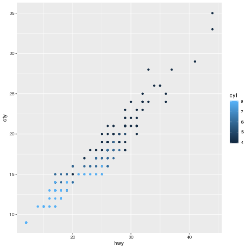

```r
ggplot(mpg) +  geom_point(aes(x = hwy, y = cty, colour = cyl))
```

### Or possibly....

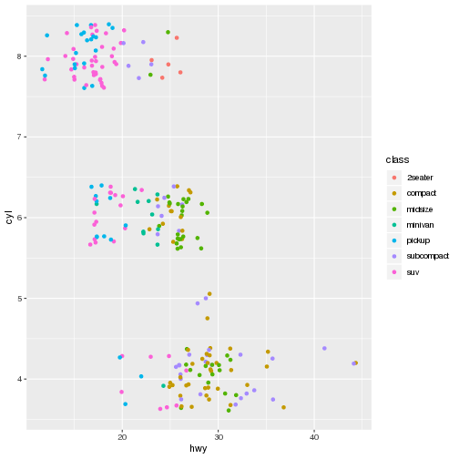

```r
ggplot(mpg) + geom_jitter(aes(x = hwy, y = cyl, colour = class))
```

- How does this differ from geom_point? Is it better?

```r
ggplot(mpg) + geom_point(aes(x = displ, y = hwy)) + geom_smooth()
```

- This doesn't work. Why?

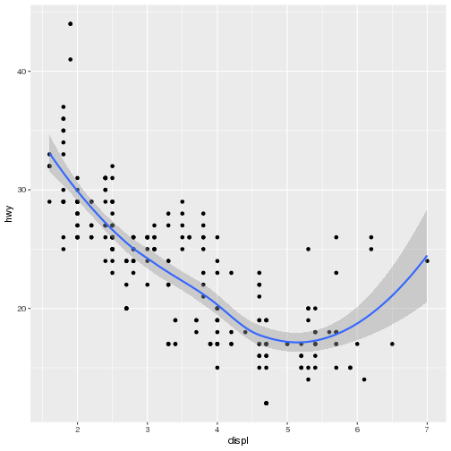

```r
ggplot(mpg, aes(displ, hwy)) + geom_point() + geom_smooth()
```

### Why isn't this useful?

```r
ggplot(mpg) + geom_point(aes(x = displ, y = hwy))
```

### Graphs are objects that you can assign to a name!

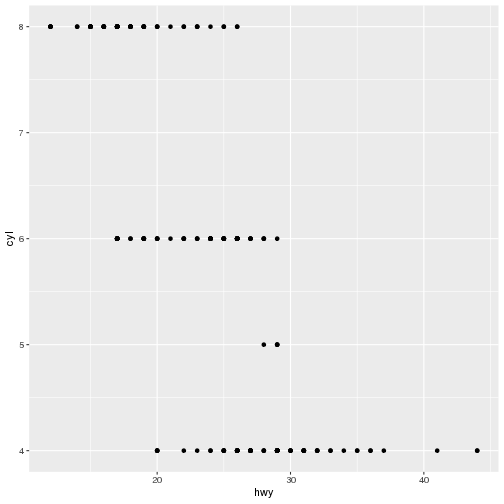

```r
myGraph <- ggplot(mpg) + geom_point(aes(x = hwy, y = cyl))
myGraph
```

### Making things a little clearer with labels

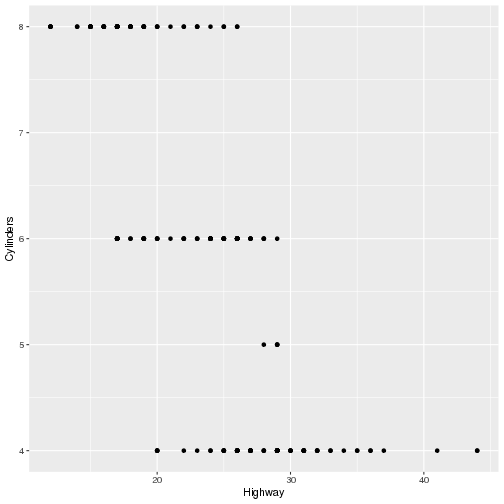

```r
myGraph + labs(x = "Highway", y = "Cylinders")
```

### And a title!

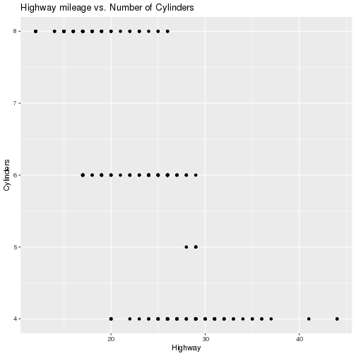

```r
myGraph + labs(x = "Highway", y = "Cylinders", title = "Highway mileage vs. Number of Cylinders")
```

### Questions/your own projects????

- https://jbfink.github.io/2019-Access-R-Class